# W3cubDocs

## hough_line

**`skimage.transform.hough_line(image, theta=None)` [[source]](http://github.com/scikit-image/scikit-image/blob/v0.14.1/skimage/transform/hough_transform.py#L166)**

Perform a straight line Hough transform.

[output not shown]

#### Notes

The origin is the top left corner of the original image. X and Y axis are horizontal and vertical edges respectively. The distance is the minimal algebraic distance from the origin to the detected line. The angle accuracy can be improved by decreasing the step size in the `theta` array.

#### Examples

Generate a test image:

```
>>> img = np.zeros((100, 150), dtype=bool)
>>> img[30, :] = 1
>>> img[:, 65] = 1
>>> img[35:45, 35:50] = 1
>>> for i in range(90):
...     img[i, i] = 1
>>> img += np.random.random(img.shape) > 0.95
```

Apply the Hough transform:

```
>>> out, angles, d = hough_line(img)
```

```
import numpy as np
import matplotlib.pyplot as plt

from skimage.transform import hough_line
from skimage.draw import line

img = np.zeros((100, 150), dtype=bool)
img[30, :] = 1
img[:, 65] = 1
img[35:45, 35:50] = 1
rr, cc = line(60, 130, 80, 10)
img[rr, cc] = 1
img += np.random.random(img.shape) > 0.95

out, angles, d = hough_line(img)

fix, axes = plt.subplots(1, 2, figsize=(7, 4))

axes[0].imshow(img, cmap=plt.cm.gray)
axes[0].set_title('Input image')

axes[1].imshow(
    out, cmap=plt.cm.bone,
    extent=(np.rad2deg(angles[-1]), np.rad2deg(angles[0]), d[-1], d[0]))
axes[1].set_title('Hough transform')
axes[1].set_xlabel('Angle (degree)')
axes[1].set_ylabel('Distance (pixel)')

plt.tight_layout()
plt.show()
```

([Source code](http://scikit-image.org/docs/0.14.x/plots/hough_tf.py), png, pdf)

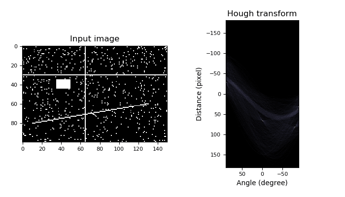

## probabilistic_hough_line

**`skimage.transform.probabilistic_hough_line(image, threshold=10, line_length=50, line_gap=10, theta=None, seed=None)` [[source]](http://github.com/scikit-image/scikit-image/blob/v0.14.1/skimage/transform/hough_transform.py#L224)**

Return lines from a progressive probabilistic line Hough transform.

[output not shown]

#### References

| [1] | C. Galamhos, J. Matas and J. Kittler, “Progressive probabilistic Hough transform for line detection”, in IEEE Computer Society Conference on Computer Vision and Pattern Recognition, 1999. |
| --- | --- |

## hough_circle_peaks

**`skimage.transform.hough_circle_peaks(hspaces, radii, min_xdistance=1, min_ydistance=1, threshold=None, num_peaks=inf, total_num_peaks=inf, normalize=False)` [[source]](http://github.com/scikit-image/scikit-image/blob/v0.14.1/skimage/transform/hough_transform.py#L269)**

Return peaks in a circle Hough transform.

Identifies most prominent circles separated by certain distances in a Hough space. Non-maximum suppression with different sizes is applied separately in the first and second dimension of the Hough space to identify peaks.

[output not shown]

#### Examples

```
>>> from skimage import transform, draw
>>> img = np.zeros((120, 100), dtype=int)
>>> radius, x_0, y_0 = (20, 99, 50)
>>> y, x = draw.circle_perimeter(y_0, x_0, radius)
>>> img[x, y] = 1
>>> hspaces = transform.hough_circle(img, radius)
>>> accum, cx, cy, rad = hough_circle_peaks(hspaces, [radius,])
```

## hough_line_peaks

**`skimage.transform.hough_line_peaks(hspace, angles, dists, min_distance=9, min_angle=10, threshold=None, num_peaks=inf)` [[source]](http://github.com/scikit-image/scikit-image/blob/v0.14.1/skimage/transform/hough_transform.py#L8)**

Return peaks in a straight line Hough transform.

Identifies most prominent lines separated by a certain angle and distance in a Hough transform. Non-maximum suppression with different sizes is applied separately in the first (distances) and second (angles) dimension of the Hough space to identify peaks.

[output not shown]

#### Examples

```
>>> from skimage.transform import hough_line, hough_line_peaks
>>> from skimage.draw import line
>>> img = np.zeros((15, 15), dtype=np.bool_)
>>> rr, cc = line(0, 0, 14, 14)
>>> img[rr, cc] = 1
>>> rr, cc = line(0, 14, 14, 0)
>>> img[cc, rr] = 1
>>> hspace, angles, dists = hough_line(img)
>>> hspace, angles, dists = hough_line_peaks(hspace, angles, dists)
>>> len(angles)
2
```

## radon

**`skimage.transform.radon(image, theta=None, circle=None)` [[source]](http://github.com/scikit-image/scikit-image/blob/v0.14.1/skimage/transform/radon_transform.py#L14)**

Calculates the radon transform of an image given specified projection angles.

[output not shown]

#### Notes

Based on code of Justin K. Romberg (http://www.clear.rice.edu/elec431/projects96/DSP/bpanalysis.html)

#### References

| [1] | AC Kak, M Slaney, “Principles of Computerized Tomographic Imaging”, IEEE Press 1988. |
| --- | --- |

[output not shown]

## iradon

**`skimage.transform.iradon(radon_image, theta=None, output_size=None, filter='ramp', interpolation='linear', circle=None)` [[source]](http://github.com/scikit-image/scikit-image/blob/v0.14.1/skimage/transform/radon_transform.py#L127)**

Inverse radon transform.

Reconstruct an image from the radon transform, using the filtered back projection algorithm.

[output not shown]

#### Notes

It applies the Fourier slice theorem to reconstruct an image by multiplying the frequency domain of the filter with the FFT of the projection data. This algorithm is called filtered back projection.

#### References

| [1] | AC Kak, M Slaney, “Principles of Computerized Tomographic Imaging”, IEEE Press 1988. |
| --- | --- |

[output not shown]

## iradon_sart

**`skimage.transform.iradon_sart(radon_image, theta=None, image=None, projection_shifts=None, clip=None, relaxation=0.15)` [[source]](http://github.com/scikit-image/scikit-image/blob/v0.14.1/skimage/transform/radon_transform.py#L329)**

Inverse radon transform

Reconstruct an image from the radon transform, using a single iteration of the Simultaneous Algebraic Reconstruction Technique (SART) algorithm.

[output not shown]

#### Notes

Algebraic Reconstruction Techniques are based on formulating the tomography reconstruction problem as a set of linear equations. Along each ray, the projected value is the sum of all the values of the cross section along the ray. A typical feature of SART (and a few other variants of algebraic techniques) is that it samples the cross section at equidistant points along the ray, using linear interpolation between the pixel values of the cross section. The resulting set of linear equations are then solved using a slightly modified Kaczmarz method.

When using SART, a single iteration is usually sufficient to obtain a good reconstruction. Further iterations will tend to enhance high-frequency information, but will also often increase the noise.

#### References

| [1] | AC Kak, M Slaney, “Principles of Computerized Tomographic Imaging”, IEEE Press 1988. |
| --- | --- |

| [2] | AH Andersen, AC Kak, “Simultaneous algebraic reconstruction technique (SART): a superior implementation of the ART algorithm”, Ultrasonic Imaging 6 pp 81–94 (1984) |
| --- | --- |

| [3] | S Kaczmarz, “Angenäherte auflösung von systemen linearer gleichungen”, Bulletin International de l’Academie Polonaise des Sciences et des Lettres 35 pp 355–357 (1937) |
| --- | --- |

| [4] | Kohler, T. “A projection access scheme for iterative reconstruction based on the golden section.” Nuclear Science Symposium Conference Record, 2004 IEEE. Vol. 6. IEEE, 2004. |
| --- | --- |

| [5] | Kaczmarz’ method, Wikipedia, http://en.wikipedia.org/wiki/Kaczmarz_method |
| --- | --- |

## order_angles_golden_ratio

**`skimage.transform.order_angles_golden_ratio(theta)` [[source]](http://github.com/scikit-image/scikit-image/blob/v0.14.1/skimage/transform/radon_transform.py#L271)**

Order angles to reduce the amount of correlated information in subsequent projections.

[output not shown]

#### Notes

The method used here is that of the golden ratio introduced by T. Kohler.

#### References

| [1] | Kohler, T. “A projection access scheme for iterative reconstruction based on the golden section.” Nuclear Science Symposium Conference Record, 2004 IEEE. Vol. 6. IEEE, 2004. |
| --- | --- |

| [2] | Winkelmann, Stefanie, et al. “An optimal radial profile order based on the Golden Ratio for time-resolved MRI.” Medical Imaging, IEEE Transactions on 26.1 (2007): 68-76. |
| --- | --- |

## frt2

**`skimage.transform.frt2(a)` [[source]](http://github.com/scikit-image/scikit-image/blob/v0.14.1/skimage/transform/finite_radon_transform.py#L12)**

Compute the 2-dimensional finite radon transform (FRT) for an n x n integer array.

| Parameters: | **`a : array_like`** A 2-D square n x n integer array. |
| --- | --- |
| Returns: | **`FRT : 2-D ndarray`** Finite Radon Transform array of (n+1) x n integer coefficients. |

See also

**`ifrt2`**

The two-dimensional inverse FRT.

#### Notes

The FRT has a unique inverse if and only if n is prime. [FRT] The idea for this algorithm is due to Vlad Negnevitski.

#### References

| [FRT] | A. Kingston and I. Svalbe, “Projective transforms on periodic discrete image arrays,” in P. Hawkes (Ed), Advances in Imaging and Electron Physics, 139 (2006) |
| --- | --- |

#### Examples

Generate a test image: Use a prime number for the array dimensions

```
>>> SIZE = 59
>>> img = np.tri(SIZE, dtype=np.int32)
```

Apply the Finite Radon Transform:

```
>>> f = frt2(img)
```

## ifrt2

**`skimage.transform.ifrt2(a)` [[source]](http://github.com/scikit-image/scikit-image/blob/v0.14.1/skimage/transform/finite_radon_transform.py#L71)**

Compute the 2-dimensional inverse finite radon transform (iFRT) for an (n+1) x n integer array.

| Parameters: | **`a : array_like`** A 2-D (n+1) row x n column integer array. |
| --- | --- |
| Returns: | **`iFRT : 2-D n x n ndarray`** Inverse Finite Radon Transform array of n x n integer coefficients. |

See also

**`frt2`**

The two-dimensional FRT

#### Notes

The FRT has a unique inverse if and only if n is prime. See [1] for an overview. The idea for this algorithm is due to Vlad Negnevitski.

#### References

| [1] | *(1, 2)* A. Kingston and I. Svalbe, “Projective transforms on periodic discrete image arrays,” in P. Hawkes (Ed), Advances in Imaging and Electron Physics, 139 (2006) |
| --- | --- |

#### Examples

```
>>> SIZE = 59
>>> img = np.tri(SIZE, dtype=np.int32)
```

Apply the Finite Radon Transform:

```
>>> f = frt2(img)
```

Apply the Inverse Finite Radon Transform to recover the input

```
>>> fi = ifrt2(f)
```

Check that it’s identical to the original

```
>>> assert len(np.nonzero(img-fi)[0]) == 0
```

## integral_image

**`skimage.transform.integral_image(image)` [[source]](http://github.com/scikit-image/scikit-image/blob/v0.14.1/skimage/transform/integral.py#L7)**

Integral image / summed area table.

The integral image contains the sum of all elements above and to the left of it, i.e.:

$S[m, n] = \sum_{i \leq m} \sum_{j \leq n} X[i, j]$

| Parameters: | **`image : ndarray`** Input image. |
| --- | --- |
| Returns: | **`S : ndarray`** Integral image/summed area table of same shape as input image. |

#### References

| [1] | F.C. Crow, “Summed-area tables for texture mapping,” ACM SIGGRAPH Computer Graphics, vol. 18, 1984, pp. 207-212. |
| --- | --- |

## integrate

**`skimage.transform.integrate(ii, start, end)` [[source]](http://github.com/scikit-image/scikit-image/blob/v0.14.1/skimage/transform/integral.py#L39)**

Use an integral image to integrate over a given window.

[output not shown]

#### Examples

```
>>> arr = np.ones((5, 6), dtype=np.float)
>>> ii = integral_image(arr)
>>> integrate(ii, (1, 0), (1, 2))  # sum from (1, 0) to (1, 2)
array([ 3.])
>>> integrate(ii, [(3, 3)], [(4, 5)])  # sum from (3, 3) to (4, 5)
array([ 6.])
>>> # sum from (1, 0) to (1, 2) and from (3, 3) to (4, 5)
>>> integrate(ii, [(1, 0), (3, 3)], [(1, 2), (4, 5)])
array([ 3.,  6.])
```

## warp

**`skimage.transform.warp(image, inverse_map, map_args={}, output_shape=None, order=1, mode='constant', cval=0.0, clip=True, preserve_range=False)` [[source]](http://github.com/scikit-image/scikit-image/blob/v0.14.1/skimage/transform/_warps.py#L663)**

Warp an image according to a given coordinate transformation.

Parameters:

**`image : ndarray`**

Input image.

**`inverse_map : transformation object, callable cr = f(cr, **kwargs), or ndarray`**

Inverse coordinate map, which transforms coordinates in the output images into their corresponding coordinates in the input image.

There are a number of different options to define this map, depending on the dimensionality of the input image. A 2-D image can have 2 dimensions for gray-scale images, or 3 dimensions with color information.

- For 2-D images, you can directly pass a transformation object, e.g. `skimage.transform.SimilarityTransform`, or its inverse.
- For 2-D images, you can pass a `(3, 3)` homogeneous transformation matrix, e.g. `skimage.transform.SimilarityTransform.params`.
- For 2-D images, a function that transforms a `(M, 2)` array of `(col, row)` coordinates in the output image to their corresponding coordinates in the input image. Extra parameters to the function can be specified through `map_args`.
- For N-D images, you can directly pass an array of coordinates. The first dimension specifies the coordinates in the input image, while the subsequent dimensions determine the position in the output image. E.g. in case of 2-D images, you need to pass an array of shape `(2, rows, cols)`, where `rows` and `cols` determine the shape of the output image, and the first dimension contains the `(row, col)` coordinate in the input image. See `scipy.ndimage.map_coordinates` for further documentation.

Note, that a `(3, 3)` matrix is interpreted as a homogeneous transformation matrix, so you cannot interpolate values from a 3-D input, if the output is of shape `(3,)`.

See example section for usage.

**`map_args : dict, optional`**

Keyword arguments passed to `inverse_map`.

**`output_shape : tuple (rows, cols), optional`**

Shape of the output image generated. By default the shape of the input image is preserved. Note that, even for multi-band images, only rows and columns need to be specified.

**`order : int, optional`**

**The order of interpolation. The order has to be in the range 0-5:**

- 0: Nearest-neighbor
- 1: Bi-linear (default)
- 2: Bi-quadratic
- 3: Bi-cubic
- 4: Bi-quartic
- 5: Bi-quintic

**`mode : {‘constant’, ‘edge’, ‘symmetric’, ‘reflect’, ‘wrap’}, optional`**

Points outside the boundaries of the input are filled according to the given mode. Modes match the behaviour of `numpy.pad`.

**`cval : float, optional`**

Used in conjunction with mode ‘constant’, the value outside the image boundaries.

**`clip : bool, optional`**

Whether to clip the output to the range of values of the input image. This is enabled by default, since higher order interpolation may produce values outside the given input range.

**`preserve_range : bool, optional`**

Whether to keep the original range of values. Otherwise, the input image is converted according to the conventions of `img_as_float`.

Returns:

**`warped : double ndarray`**

The warped input image.

#### Notes

- The input image is converted to a `double` image.
- In case of a `SimilarityTransform`, `AffineTransform` and `ProjectiveTransform` and `order` in [0, 3] this function uses the underlying transformation matrix to warp the image with a much faster routine.

#### Examples

```
>>> from skimage.transform import warp
>>> from skimage import data
>>> image = data.camera()
```

The following image warps are all equal but differ substantially in execution time. The image is shifted to the bottom.

Use a geometric transform to warp an image (fast):

```
>>> from skimage.transform import SimilarityTransform
>>> tform = SimilarityTransform(translation=(0, -10))
>>> warped = warp(image, tform)
```

Use a callable (slow):

```
>>> def shift_down(xy):
...     xy[:, 1] -= 10
...     return xy
>>> warped = warp(image, shift_down)
```

Use a transformation matrix to warp an image (fast):

```
>>> matrix = np.array([[1, 0, 0], [0, 1, -10], [0, 0, 1]])
>>> warped = warp(image, matrix)
>>> from skimage.transform import ProjectiveTransform
>>> warped = warp(image, ProjectiveTransform(matrix=matrix))
```

You can also use the inverse of a geometric transformation (fast):

```
>>> warped = warp(image, tform.inverse)
```

For N-D images you can pass a coordinate array, that specifies the coordinates in the input image for every element in the output image. E.g. if you want to rescale a 3-D cube, you can do:

```
>>> cube_shape = np.array([30, 30, 30])
>>> cube = np.random.rand(*cube_shape)
```

Setup the coordinate array, that defines the scaling:

```
>>> scale = 0.1
>>> output_shape = (scale * cube_shape).astype(int)
>>> coords0, coords1, coords2 = np.mgrid[:output_shape[0],
...                    :output_shape[1], :output_shape[2]]
>>> coords = np.array([coords0, coords1, coords2])
```

Assume that the cube contains spatial data, where the first array element center is at coordinate (0.5, 0.5, 0.5) in real space, i.e. we have to account for this extra offset when scaling the image:

```
>>> coords = (coords + 0.5) / scale - 0.5
>>> warped = warp(cube, coords)
```

## warp_coords

**`skimage.transform.warp_coords(coord_map, shape, dtype=<class 'numpy.float64'>)` [[source]](http://github.com/scikit-image/scikit-image/blob/v0.14.1/skimage/transform/_warps.py#L539)**

Build the source coordinates for the output of a 2-D image warp.

[output not shown]

#### Notes

This is a lower-level routine that produces the source coordinates for 2-D images used by `warp()`.

It is provided separately from `warp` to give additional flexibility to users who would like, for example, to re-use a particular coordinate mapping, to use specific dtypes at various points along the the image-warping process, or to implement different post-processing logic than `warp` performs after the call to `ndi.map_coordinates`.

#### Examples

```
>>> from skimage import data
>>> from scipy.ndimage import map_coordinates
>>>
>>> def shift_up10_left20(xy):
...     return xy - np.array([-20, 10])[None, :]
>>>
>>> image = data.astronaut().astype(np.float32)
>>> coords = warp_coords(shift_up10_left20, image.shape)
>>> warped_image = map_coordinates(image, coords)
```

## estimate_transform

**`skimage.transform.estimate_transform(ttype, src, dst, **kwargs)` [[source]](http://github.com/scikit-image/scikit-image/blob/v0.14.1/skimage/transform/_geometric.py#L1307)**

Estimate 2D geometric transformation parameters.

You can determine the over-, well- and under-determined parameters with the total least-squares method.

Number of source and destination coordinates must match.

Parameters:

**`ttype : {‘euclidean’, similarity’, ‘affine’, ‘piecewise-affine’, ‘projective’, ‘polynomial’}`**

Type of transform.

**`kwargs : array or int`**

Function parameters (src, dst, n, angle):

```
NAME / TTYPE        FUNCTION PARAMETERS
'euclidean'         `src, `dst`
'similarity'        `src, `dst`
'affine'            `src, `dst`
'piecewise-affine'  `src, `dst`
'projective'        `src, `dst`
'polynomial'        `src, `dst`, `order` (polynomial order,
                                          default order is 2)
```

Also see examples below.

Returns:

**`tform : GeometricTransform`**

Transform object containing the transformation parameters and providing access to forward and inverse transformation functions.

#### Examples

```
>>> import numpy as np
>>> from skimage import transform as tf
```

```
>>> # estimate transformation parameters
>>> src = np.array([0, 0, 10, 10]).reshape((2, 2))
>>> dst = np.array([12, 14, 1, -20]).reshape((2, 2))
```

```
>>> tform = tf.estimate_transform('similarity', src, dst)
```

```
>>> np.allclose(tform.inverse(tform(src)), src)
True
```

```
>>> # warp image using the estimated transformation
>>> from skimage import data
>>> image = data.camera()
```

```
>>> warp(image, inverse_map=tform.inverse) # doctest: +SKIP
```

```
>>> # create transformation with explicit parameters
>>> tform2 = tf.SimilarityTransform(scale=1.1, rotation=1,
...     translation=(10, 20))
```

```
>>> # unite transformations, applied in order from left to right
>>> tform3 = tform + tform2
>>> np.allclose(tform3(src), tform2(tform(src)))
True
```

## matrix_transform

**`skimage.transform.matrix_transform(coords, matrix)` [[source]](http://github.com/scikit-image/scikit-image/blob/v0.14.1/skimage/transform/_geometric.py#L1381)**

Apply 2D matrix transform.

| Parameters: | **`coords : (N, 2) array`** x, y coordinates to transform **`matrix : (3, 3) array`** Homogeneous transformation matrix. |
| --- | --- |
| Returns: | **`coords : (N, 2) array`** Transformed coordinates. |

## swirl

**`skimage.transform.swirl(image, center=None, strength=1, radius=100, rotation=0, output_shape=None, order=1, mode=None, cval=0, clip=True, preserve_range=False)` [[source]](http://github.com/scikit-image/scikit-image/blob/v0.14.1/skimage/transform/_warps.py#L450)**

Perform a swirl transformation.

[output not shown]

## resize

**`skimage.transform.resize(image, output_shape, order=1, mode=None, cval=0, clip=True, preserve_range=False, anti_aliasing=None, anti_aliasing_sigma=None)` [[source]](http://github.com/scikit-image/scikit-image/blob/v0.14.1/skimage/transform/_warps.py#L34)**

Resize image to match a certain size.

Performs interpolation to up-size or down-size images. Note that anti- aliasing should be enabled when down-sizing images to avoid aliasing artifacts. For down-sampling N-dimensional images with an integer factor also see `skimage.transform.downscale_local_mean`.

[output not shown]

#### Notes

Modes ‘reflect’ and ‘symmetric’ are similar, but differ in whether the edge pixels are duplicated during the reflection. As an example, if an array has values [0, 1, 2] and was padded to the right by four values using symmetric, the result would be [0, 1, 2, 2, 1, 0, 0], while for reflect it would be [0, 1, 2, 1, 0, 1, 2].

#### Examples

```
>>> from skimage import data
>>> from skimage.transform import resize
>>> image = data.camera()
>>> resize(image, (100, 100), mode='reflect').shape
(100, 100)
```

## rotate

**`skimage.transform.rotate(image, angle, resize=False, center=None, order=1, mode='constant', cval=0, clip=True, preserve_range=False)` [[source]](http://github.com/scikit-image/scikit-image/blob/v0.14.1/skimage/transform/_warps.py#L285)**

Rotate image by a certain angle around its center.

[output not shown]

#### Notes

Modes ‘reflect’ and ‘symmetric’ are similar, but differ in whether the edge pixels are duplicated during the reflection. As an example, if an array has values [0, 1, 2] and was padded to the right by four values using symmetric, the result would be [0, 1, 2, 2, 1, 0, 0], while for reflect it would be [0, 1, 2, 1, 0, 1, 2].

#### Examples

```
>>> from skimage import data
>>> from skimage.transform import rotate
>>> image = data.camera()
>>> rotate(image, 2).shape
(512, 512)
>>> rotate(image, 2, resize=True).shape
(530, 530)
>>> rotate(image, 90, resize=True).shape
(512, 512)
```

## rescale

**`skimage.transform.rescale(image, scale, order=1, mode=None, cval=0, clip=True, preserve_range=False, multichannel=None, anti_aliasing=None, anti_aliasing_sigma=None)` [[source]](http://github.com/scikit-image/scikit-image/blob/v0.14.1/skimage/transform/_warps.py#L190)**

Scale image by a certain factor.

Performs interpolation to up-scale or down-scale images. Note that anti- aliasing should be enabled when down-sizing images to avoid aliasing artifacts. For down-sampling N-dimensional images with an integer factor also see `skimage.transform.downscale_local_mean`.

[output not shown]

#### Notes

Modes ‘reflect’ and ‘symmetric’ are similar, but differ in whether the edge pixels are duplicated during the reflection. As an example, if an array has values [0, 1, 2] and was padded to the right by four values using symmetric, the result would be [0, 1, 2, 2, 1, 0, 0], while for reflect it would be [0, 1, 2, 1, 0, 1, 2].

#### Examples

```
>>> from skimage import data
>>> from skimage.transform import rescale
>>> image = data.camera()
>>> rescale(image, 0.1, mode='reflect').shape
(51, 51)
>>> rescale(image, 0.5, mode='reflect').shape
(256, 256)
```

## downscale_local_mean

**`skimage.transform.downscale_local_mean(image, factors, cval=0, clip=True)` [[source]](http://github.com/scikit-image/scikit-image/blob/v0.14.1/skimage/transform/_warps.py#L390)**

Down-sample N-dimensional image by local averaging.

The image is padded with `cval` if it is not perfectly divisible by the integer factors.

In contrast to the 2-D interpolation in `skimage.transform.resize` and `skimage.transform.rescale` this function may be applied to N-dimensional images and calculates the local mean of elements in each block of size `factors` in the input image.

[output not shown]

#### Examples

```
>>> a = np.arange(15).reshape(3, 5)
>>> a
array([[ 0,  1,  2,  3,  4],
       [ 5,  6,  7,  8,  9],
       [10, 11, 12, 13, 14]])
>>> downscale_local_mean(a, (2, 3))
array([[ 3.5,  4. ],
       [ 5.5,  4.5]])
```

## pyramid_reduce

**`skimage.transform.pyramid_reduce(image, downscale=2, sigma=None, order=1, mode='reflect', cval=0, multichannel=None)` [[source]](http://github.com/scikit-image/scikit-image/blob/v0.14.1/skimage/transform/pyramids.py#L27)**

Smooth and then downsample image.

[output not shown]

#### References

| [1] | http://web.mit.edu/persci/people/adelson/pub_pdfs/pyramid83.pdf |
| --- | --- |

## pyramid_expand

**`skimage.transform.pyramid_expand(image, upscale=2, sigma=None, order=1, mode='reflect', cval=0, multichannel=None)` [[source]](http://github.com/scikit-image/scikit-image/blob/v0.14.1/skimage/transform/pyramids.py#L85)**

Upsample and then smooth image.

[output not shown]

#### References

| [1] | http://web.mit.edu/persci/people/adelson/pub_pdfs/pyramid83.pdf |
| --- | --- |

## pyramid_gaussian

**`skimage.transform.pyramid_gaussian(image, max_layer=-1, downscale=2, sigma=None, order=1, mode='reflect', cval=0, multichannel=None)` [[source]](http://github.com/scikit-image/scikit-image/blob/v0.14.1/skimage/transform/pyramids.py#L144)**

Yield images of the Gaussian pyramid formed by the input image.

Recursively applies the `pyramid_reduce` function to the image, and yields the downscaled images.

Note that the first image of the pyramid will be the original, unscaled image. The total number of images is `max_layer + 1`. In case all layers are computed, the last image is either a one-pixel image or the image where the reduction does not change its shape.

[output not shown]

#### References

| [1] | http://web.mit.edu/persci/people/adelson/pub_pdfs/pyramid83.pdf |
| --- | --- |

## pyramid_laplacian

**`skimage.transform.pyramid_laplacian(image, max_layer=-1, downscale=2, sigma=None, order=1, mode='reflect', cval=0, multichannel=None)` [[source]](http://github.com/scikit-image/scikit-image/blob/v0.14.1/skimage/transform/pyramids.py#L224)**

Yield images of the laplacian pyramid formed by the input image.

Each layer contains the difference between the downsampled and the downsampled, smoothed image:

```
layer = resize(prev_layer) - smooth(resize(prev_layer))
```

Note that the first image of the pyramid will be the difference between the original, unscaled image and its smoothed version. The total number of images is `max_layer + 1`. In case all layers are computed, the last image is either a one-pixel image or the image where the reduction does not change its shape.

[output not shown]

#### References

| [1] | http://web.mit.edu/persci/people/adelson/pub_pdfs/pyramid83.pdf |
| --- | --- |

| [2] | http://sepwww.stanford.edu/data/media/public/sep/morgan/texturematch/paper_html/node3.html |
| --- | --- |

## seam_carve

**`skimage.transform.seam_carve(image, energy_map, mode, num, border=1, force_copy=True)` [[source]](http://github.com/scikit-image/scikit-image/blob/v0.14.1/skimage/transform/seam_carving.py#L7)**

Carve vertical or horizontal seams off an image.

Carves out vertical/horizontal seams from an image while using the given energy map to decide the importance of each pixel.

[output not shown]

#### References

| [1] | Shai Avidan and Ariel Shamir “Seam Carving for Content-Aware Image Resizing” http://www.cs.jhu.edu/~misha/ReadingSeminar/Papers/Avidan07.pdf |
| --- | --- |

## EuclideanTransform

**`class skimage.transform.EuclideanTransform(matrix=None, rotation=None, translation=None)` [[source]](http://github.com/scikit-image/scikit-image/blob/v0.14.1/skimage/transform/_geometric.py#L942)**

Bases: `skimage.transform._geometric.ProjectiveTransform`

2D Euclidean transformation.

Has the following form:

```
X = a0 * x - b0 * y + a1 =
  = x * cos(rotation) - y * sin(rotation) + a1

Y = b0 * x + a0 * y + b1 =
  = x * sin(rotation) + y * cos(rotation) + b1
```

where the homogeneous transformation matrix is:

```
[[a0  b0  a1]
 [b0  a0  b1]
 [0   0    1]]
```

The Euclidean transformation is a rigid transformation with rotation and translation parameters. The similarity transformation extends the Euclidean transformation with a single scaling factor.

[output not shown]

**`__init__(matrix=None, rotation=None, translation=None)` [[source]](http://github.com/scikit-image/scikit-image/blob/v0.14.1/skimage/transform/_geometric.py#L979)**

Initialize self. See help(type(self)) for accurate signature.

**`estimate(src, dst)` [[source]](http://github.com/scikit-image/scikit-image/blob/v0.14.1/skimage/transform/_geometric.py#L1006)**

Estimate the transformation from a set of corresponding points.

You can determine the over-, well- and under-determined parameters with the total least-squares method.

Number of source and destination coordinates must match.

| Parameters: | **`src : (N, 2) array`** Source coordinates. **`dst : (N, 2) array`** Destination coordinates. |
| --- | --- |
| Returns: | **`success : bool`** True, if model estimation succeeds. |

**`rotation`**

**`translation`**

## SimilarityTransform

**`class skimage.transform.SimilarityTransform(matrix=None, scale=None, rotation=None, translation=None)` [[source]](http://github.com/scikit-image/scikit-image/blob/v0.14.1/skimage/transform/_geometric.py#L1041)**

Bases: `skimage.transform._geometric.EuclideanTransform`

2D similarity transformation.

Has the following form:

```
X = a0 * x - b0 * y + a1 =
  = s * x * cos(rotation) - s * y * sin(rotation) + a1

Y = b0 * x + a0 * y + b1 =
  = s * x * sin(rotation) + s * y * cos(rotation) + b1
```

where `s` is a scale factor and the homogeneous transformation matrix is:

```
[[a0  b0  a1]
 [b0  a0  b1]
 [0   0    1]]
```

The similarity transformation extends the Euclidean transformation with a single scaling factor in addition to the rotation and translation parameters.

[output not shown]

**`__init__(matrix=None, scale=None, rotation=None, translation=None)` [[source]](http://github.com/scikit-image/scikit-image/blob/v0.14.1/skimage/transform/_geometric.py#L1080)**

Initialize self. See help(type(self)) for accurate signature.

**`estimate(src, dst)` [[source]](http://github.com/scikit-image/scikit-image/blob/v0.14.1/skimage/transform/_geometric.py#L1111)**

Estimate the transformation from a set of corresponding points.

You can determine the over-, well- and under-determined parameters with the total least-squares method.

Number of source and destination coordinates must match.

| Parameters: | **`src : (N, 2) array`** Source coordinates. **`dst : (N, 2) array`** Destination coordinates. |
| --- | --- |
| Returns: | **`success : bool`** True, if model estimation succeeds. |

**`scale`**

## AffineTransform

**`class skimage.transform.AffineTransform(matrix=None, scale=None, rotation=None, shear=None, translation=None)` [[source]](http://github.com/scikit-image/scikit-image/blob/v0.14.1/skimage/transform/_geometric.py#L715)**

Bases: `skimage.transform._geometric.ProjectiveTransform`

2D affine transformation.

Has the following form:

```
X = a0*x + a1*y + a2 =
  = sx*x*cos(rotation) - sy*y*sin(rotation + shear) + a2

Y = b0*x + b1*y + b2 =
  = sx*x*sin(rotation) + sy*y*cos(rotation + shear) + b2
```

where `sx` and `sy` are scale factors in the x and y directions, and the homogeneous transformation matrix is:

```
[[a0  a1  a2]
 [b0  b1  b2]
 [0   0    1]]
```

[output not shown]

**`__init__(matrix=None, scale=None, rotation=None, shear=None, translation=None)` [[source]](http://github.com/scikit-image/scikit-image/blob/v0.14.1/skimage/transform/_geometric.py#L755)**

Initialize self. See help(type(self)) for accurate signature.

**`rotation`**

**`scale`**

**`shear`**

**`translation`**

## ProjectiveTransform

**`class skimage.transform.ProjectiveTransform(matrix=None)` [[source]](http://github.com/scikit-image/scikit-image/blob/v0.14.1/skimage/transform/_geometric.py#L495)**

Bases: `skimage.transform._geometric.GeometricTransform`

Projective transformation.

Apply a projective transformation (homography) on coordinates.

For each homogeneous coordinate $\mathbf{x} = [x, y, 1]^T$, its target position is calculated by multiplying with the given matrix, $H$, to give $H \mathbf{x}$:

```
[[a0 a1 a2]
 [b0 b1 b2]
 [c0 c1 1 ]].
```

E.g., to rotate by theta degrees clockwise, the matrix should be:

```
[[cos(theta) -sin(theta) 0]
 [sin(theta)  cos(theta) 0]
 [0            0         1]]
```

or, to translate x by 10 and y by 20:

```
[[1 0 10]
 [0 1 20]
 [0 0 1 ]].
```

| Parameters: | **`matrix : (3, 3) array, optional`** Homogeneous transformation matrix. |
| --- | --- |
| Attributes: | **`params : (3, 3) array`** Homogeneous transformation matrix. |

**`__init__(matrix=None)` [[source]](http://github.com/scikit-image/scikit-image/blob/v0.14.1/skimage/transform/_geometric.py#L534)**

Initialize self. See help(type(self)) for accurate signature.

**`estimate(src, dst)` [[source]](http://github.com/scikit-image/scikit-image/blob/v0.14.1/skimage/transform/_geometric.py#L591)**

Estimate the transformation from a set of corresponding points.

You can determine the over-, well- and under-determined parameters with the total least-squares method.

Number of source and destination coordinates must match.

The transformation is defined as:

```
X = (a0*x + a1*y + a2) / (c0*x + c1*y + 1)
Y = (b0*x + b1*y + b2) / (c0*x + c1*y + 1)
```

These equations can be transformed to the following form:

```
0 = a0*x + a1*y + a2 - c0*x*X - c1*y*X - X
0 = b0*x + b1*y + b2 - c0*x*Y - c1*y*Y - Y
```

which exist for each set of corresponding points, so we have a set of N * 2 equations. The coefficients appear linearly so we can write A x = 0, where:

```
A   = [[x y 1 0 0 0 -x*X -y*X -X]
       [0 0 0 x y 1 -x*Y -y*Y -Y]
        ...
        ...
      ]
x.T = [a0 a1 a2 b0 b1 b2 c0 c1 c3]
```

In case of total least-squares the solution of this homogeneous system of equations is the right singular vector of A which corresponds to the smallest singular value normed by the coefficient c3.

In case of the affine transformation the coefficients c0 and c1 are 0. Thus the system of equations is:

```
A   = [[x y 1 0 0 0 -X]
       [0 0 0 x y 1 -Y]
        ...
        ...
      ]
x.T = [a0 a1 a2 b0 b1 b2 c3]
```

| Parameters: | **`src : (N, 2) array`** Source coordinates. **`dst : (N, 2) array`** Destination coordinates. |
| --- | --- |
| Returns: | **`success : bool`** True, if model estimation succeeds. |

**`inverse(coords)` [[source]](http://github.com/scikit-image/scikit-image/blob/v0.14.1/skimage/transform/_geometric.py#L575)**

Apply inverse transformation.

| Parameters: | **`coords : (N, 2) array`** Destination coordinates. |
| --- | --- |
| Returns: | **`coords : (N, 2) array`** Source coordinates. |

## EssentialMatrixTransform

**`class skimage.transform.EssentialMatrixTransform(rotation=None, translation=None, matrix=None)` [[source]](http://github.com/scikit-image/scikit-image/blob/v0.14.1/skimage/transform/_geometric.py#L397)**

Bases: `skimage.transform._geometric.FundamentalMatrixTransform`

Essential matrix transformation.

The essential matrix relates corresponding points between a pair of calibrated images. The matrix transforms normalized, homogeneous image points in one image to epipolar lines in the other image.

The essential matrix is only defined for a pair of moving images capturing a non-planar scene. In the case of pure rotation or planar scenes, the homography describes the geometric relation between two images (`ProjectiveTransform`). If the intrinsic calibration of the images is unknown, the fundamental matrix describes the projective relation between the two images (`FundamentalMatrixTransform`).

[output not shown]

#### References

| [1] | Hartley, Richard, and Andrew Zisserman. Multiple view geometry in computer vision. Cambridge university press, 2003. |
| --- | --- |

| Attributes: | **`params : (3, 3) array`** Essential matrix. |
| --- | --- |

**`__init__(rotation=None, translation=None, matrix=None)` [[source]](http://github.com/scikit-image/scikit-image/blob/v0.14.1/skimage/transform/_geometric.py#L433)**

Initialize self. See help(type(self)) for accurate signature.

**`estimate(src, dst)` [[source]](http://github.com/scikit-image/scikit-image/blob/v0.14.1/skimage/transform/_geometric.py#L458)**

Estimate essential matrix using 8-point algorithm.

The 8-point algorithm requires at least 8 corresponding point pairs for a well-conditioned solution, otherwise the over-determined solution is estimated.

| Parameters: | **`src : (N, 2) array`** Source coordinates. **`dst : (N, 2) array`** Destination coordinates. |
| --- | --- |
| Returns: | **`success : bool`** True, if model estimation succeeds. |

## FundamentalMatrixTransform

**`class skimage.transform.FundamentalMatrixTransform(matrix=None)` [[source]](http://github.com/scikit-image/scikit-image/blob/v0.14.1/skimage/transform/_geometric.py#L211)**

Bases: `skimage.transform._geometric.GeometricTransform`

Fundamental matrix transformation.

The fundamental matrix relates corresponding points between a pair of uncalibrated images. The matrix transforms homogeneous image points in one image to epipolar lines in the other image.

The fundamental matrix is only defined for a pair of moving images. In the case of pure rotation or planar scenes, the homography describes the geometric relation between two images (`ProjectiveTransform`). If the intrinsic calibration of the images is known, the essential matrix describes the metric relation between the two images (`EssentialMatrixTransform`).

| Parameters: | **`matrix : (3, 3) array, optional`** Fundamental matrix. |
| --- | --- |

#### References

| [1] | Hartley, Richard, and Andrew Zisserman. Multiple view geometry in computer vision. Cambridge university press, 2003. |
| --- | --- |

| Attributes: | **`params : (3, 3) array`** Fundamental matrix. |
| --- | --- |

**`__init__(matrix=None)` [[source]](http://github.com/scikit-image/scikit-image/blob/v0.14.1/skimage/transform/_geometric.py#L241)**

Initialize self. See help(type(self)) for accurate signature.

**`estimate(src, dst)` [[source]](http://github.com/scikit-image/scikit-image/blob/v0.14.1/skimage/transform/_geometric.py#L333)**

Estimate fundamental matrix using 8-point algorithm.

The 8-point algorithm requires at least 8 corresponding point pairs for a well-conditioned solution, otherwise the over-determined solution is estimated.

| Parameters: | **`src : (N, 2) array`** Source coordinates. **`dst : (N, 2) array`** Destination coordinates. |
| --- | --- |
| Returns: | **`success : bool`** True, if model estimation succeeds. |

**`inverse(coords)` [[source]](http://github.com/scikit-image/scikit-image/blob/v0.14.1/skimage/transform/_geometric.py#L266)**

Apply inverse transformation.

| Parameters: | **`coords : (N, 2) array`** Destination coordinates. |
| --- | --- |
| Returns: | **`coords : (N, 3) array`** Epipolar lines in the source image. |

**`residuals(src, dst)` [[source]](http://github.com/scikit-image/scikit-image/blob/v0.14.1/skimage/transform/_geometric.py#L367)**

Compute the Sampson distance.

The Sampson distance is the first approximation to the geometric error.

| Parameters: | **`src : (N, 2) array`** Source coordinates. **`dst : (N, 2) array`** Destination coordinates. |
| --- | --- |
| Returns: | **`residuals : (N, ) array`** Sampson distance. |

## PolynomialTransform

**`class skimage.transform.PolynomialTransform(params=None)` [[source]](http://github.com/scikit-image/scikit-image/blob/v0.14.1/skimage/transform/_geometric.py#L1147)**

Bases: `skimage.transform._geometric.GeometricTransform`

2D polynomial transformation.

Has the following form:

```
X = sum[j=0:order]( sum[i=0:j]( a_ji * x**(j - i) * y**i ))
Y = sum[j=0:order]( sum[i=0:j]( b_ji * x**(j - i) * y**i ))
```

| Parameters: | **`params : (2, N) array, optional`** Polynomial coefficients where `N * 2 = (order + 1) * (order + 2)`. So, a_ji is defined in `params[0, :]` and b_ji in `params[1, :]`. |
| --- | --- |
| Attributes: | **`params : (2, N) array`** Polynomial coefficients where `N * 2 = (order + 1) * (order + 2)`. So, a_ji is defined in `params[0, :]` and b_ji in `params[1, :]`. |

**`__init__(params=None)` [[source]](http://github.com/scikit-image/scikit-image/blob/v0.14.1/skimage/transform/_geometric.py#L1169)**

Initialize self. See help(type(self)) for accurate signature.

**`estimate(src, dst, order=2)` [[source]](http://github.com/scikit-image/scikit-image/blob/v0.14.1/skimage/transform/_geometric.py#L1177)**

Estimate the transformation from a set of corresponding points.

You can determine the over-, well- and under-determined parameters with the total least-squares method.

Number of source and destination coordinates must match.

The transformation is defined as:

```
X = sum[j=0:order]( sum[i=0:j]( a_ji * x**(j - i) * y**i ))
Y = sum[j=0:order]( sum[i=0:j]( b_ji * x**(j - i) * y**i ))
```

These equations can be transformed to the following form:

```
0 = sum[j=0:order]( sum[i=0:j]( a_ji * x**(j - i) * y**i )) - X
0 = sum[j=0:order]( sum[i=0:j]( b_ji * x**(j - i) * y**i )) - Y
```

which exist for each set of corresponding points, so we have a set of N * 2 equations. The coefficients appear linearly so we can write A x = 0, where:

```
A   = [[1 x y x**2 x*y y**2 ... 0 ...             0 -X]
       [0 ...                 0 1 x y x**2 x*y y**2 -Y]
        ...
        ...
      ]
x.T = [a00 a10 a11 a20 a21 a22 ... ann
       b00 b10 b11 b20 b21 b22 ... bnn c3]
```

In case of total least-squares the solution of this homogeneous system of equations is the right singular vector of A which corresponds to the smallest singular value normed by the coefficient c3.

| Parameters: | **`src : (N, 2) array`** Source coordinates. **`dst : (N, 2) array`** Destination coordinates. **`order : int, optional`** Polynomial order (number of coefficients is order + 1). |
| --- | --- |
| Returns: | **`success : bool`** True, if model estimation succeeds. |

**`inverse(coords)` [[source]](http://github.com/scikit-image/scikit-image/blob/v0.14.1/skimage/transform/_geometric.py#L1287)**

Apply inverse transformation.

| Parameters: | **`coords : (N, 2) array`** Destination coordinates. |
| --- | --- |
| Returns: | **`coords : (N, 2) array`** Source coordinates. |

## PiecewiseAffineTransform

**`class skimage.transform.PiecewiseAffineTransform` [[source]](http://github.com/scikit-image/scikit-image/blob/v0.14.1/skimage/transform/_geometric.py#L808)**

Bases: `skimage.transform._geometric.GeometricTransform`

2D piecewise affine transformation.

Control points are used to define the mapping. The transform is based on a Delaunay triangulation of the points to form a mesh. Each triangle is used to find a local affine transform.

[output not shown]

**`__init__()` [[source]](http://github.com/scikit-image/scikit-image/blob/v0.14.1/skimage/transform/_geometric.py#L824)**

Initialize self. See help(type(self)) for accurate signature.

**`estimate(src, dst)` [[source]](http://github.com/scikit-image/scikit-image/blob/v0.14.1/skimage/transform/_geometric.py#L830)**

Estimate the transformation from a set of corresponding points.

Number of source and destination coordinates must match.

| Parameters: | **`src : (N, 2) array`** Source coordinates. **`dst : (N, 2) array`** Destination coordinates. |
| --- | --- |
| Returns: | **`success : bool`** True, if model estimation succeeds. |

**`inverse(coords)` [[source]](http://github.com/scikit-image/scikit-image/blob/v0.14.1/skimage/transform/_geometric.py#L906)**

Apply inverse transformation.

Coordinates outside of the mesh will be set to `- 1`.

| Parameters: | **`coords : (N, 2) array`** Source coordinates. |
| --- | --- |
| Returns: | **`coords : (N, 2) array`** Transformed coordinates. |